# assignment

Rebecca Waag

8 3 2023

# Week2: Genome builds, transcriptome assemblies and annotations

## Exercise2: AnnotationsHub, Genomic Range, Features and their manipulation in R

```r
#load libraries
suppressPackageStartupMessages({
  library(AnnotationHub)
  library(ensembldb)
  library(GenomicRanges)
  library(epiwraps)
})
```

### AnnotationHub

Using AnnotationHub, find and download the following annotations data: ○ The mouse (Mus Musculus) EnsDb object, version 102, genome build GRCm38 ○ The mouse genome sequence ( dna_sm ) in TwoBit/2bit format for GRCm38 ○ The drosophila melanogaster genome sequence ( dna_sm ) in TwoBit/2bit format for BDGP6

#### find and dowload mouse (Mus musculus) EnsDb object, version 102, genome build GRCm38

```r
ah <- AnnotationHub()
```

```
## snapshotDate(): 2022-10-31
```

```r
q <- query(ah, c("Mus musculus", "EnsDb", "version 102","GRCm38"))
q #only 1 record found: AH89211
```

```
## AnnotationHub with 1 record
## # snapshotDate(): 2022-10-31
## # names(): AH89211
## # $dataprovider: Ensembl
## # $species: Mus musculus
## # $rdataclass: EnsDb
## # $rdatadateadded: 2020-10-27
## # $title: Ensembl 102 EnsDb for Mus musculus
## # $description: Gene and protein annotations for Mus musculus based on Ensem...
## # $taxonomyid: 10090
## # $genome: GRCm38
## # $sourcetype: ensembl
## # $sourceurl: http://www.ensembl.org
## # $sourcesize: NA
## # $tags: c("102", "AHEnsDbs", "Annotation", "EnsDb", "Ensembl", "Gene",
## #   "Protein", "Transcript")
## # retrieve record with 'object[["AH89211"]]'
```

```r
ensdb_m102 <- ah[["AH89211"]]
```

```
## loading from cache
```

```r
ensdb_m102
```

```
## EnsDb for Ensembl:
## |Backend: SQLite
## |Db type: EnsDb
## |Type of Gene ID: Ensembl Gene ID
## |Supporting package: ensembldb
## |Db created by: ensembldb package from Bioconductor
## |script_version: 0.3.6
## |Creation time: Sun Dec 20 12:15:16 2020
## |ensembl_version: 102
## |ensembl_host: localhost
## |Organism: Mus musculus
## |taxonomy_id: 10090
## |genome_build: GRCm38
## |DBSCHEMAVERSION: 2.1
## | No. of genes: 56305.
## | No. of transcripts: 144778.
## |Protein data available.
```

#### find and dowload mouse genome sequence (dna_sm) in TwoBit/2bit format for GRCm38

```r
#ah <- AnnotationHub()
q <- query(ah, c("Mus musculus", "dna_sm", "2bit", "GRCm38"))
q #19 records found, I decided for the most recent entry: AH88477
```

```
## AnnotationHub with 19 records
## # snapshotDate(): 2022-10-31
## # $dataprovider: Ensembl
## # $species: Mus musculus, mus musculus
## # $rdataclass: TwoBitFile
## # additional mcols(): taxonomyid, genome, description,
## #   coordinate_1_based, maintainer, rdatadateadded, preparerclass, tags,
## #   rdatapath, sourceurl, sourcetype
## # retrieve records with, e.g., 'object[["AH49775"]]'
##
##             title
##   AH49775 | Mus_musculus.GRCm38.dna_sm.primary_assembly.2bit
##   AH50120 | Mus_musculus.GRCm38.dna_sm.primary_assembly.2bit
##   AH50611 | Mus_musculus.GRCm38.dna_sm.primary_assembly.2bit
##   AH51299 | Mus_musculus.GRCm38.dna_sm.primary_assembly.2bit
##   AH51645 | Mus_musculus.GRCm38.dna_sm.primary_assembly.2bit
##   ...       ...
##   AH70177 | Mus_musculus.GRCm38.dna_sm.primary_assembly.2bit
##   AH77927 | Mus_musculus.GRCm38.dna_sm.primary_assembly.2bit
##   AH82549 | Mus_musculus.GRCm38.dna_sm.primary_assembly.2bit
##   AH84787 | Mus_musculus.GRCm38.dna_sm.primary_assembly.2bit
##   AH88477 | Mus_musculus.GRCm38.dna_sm.primary_assembly.2bit
```

```r
ensdb_m2bit <- ah[["AH88477"]]
```

```
## loading from cache
```

```
## require("rtracklayer")
```

```r
ensdb_m2bit
```

```
## TwoBitFile object
## resource: C:\Users\rebec\AppData\Local/R/cache/R/AnnotationHub/92407d20cdd_95223
```

#### find and dowload drosophila melanogaster genome sequence ( dna_sm ) in TwoBit/2bit format for BDGP6

```r
#ah <- AnnotationHub()
q <- query(ah, c("Drosophila melanogaster", "dna_sm", "2bit", "BDGP6"))
q #24 entries, I decided for the most recent entry: AH106160
```

```
## AnnotationHub with 24 records
## # snapshotDate(): 2022-10-31
## # $dataprovider: Ensembl
## # $species: Drosophila melanogaster, drosophila melanogaster
## # $rdataclass: TwoBitFile
## # additional mcols(): taxonomyid, genome, description,
## #   coordinate_1_based, maintainer, rdatadateadded, preparerclass, tags,
## #   rdatapath, sourceurl, sourcetype
## # retrieve records with, e.g., 'object[["AH49674"]]'
##
##              title
##   AH49674  | Drosophila_melanogaster.BDGP6.dna_sm.toplevel.2bit
##   AH50019  | Drosophila_melanogaster.BDGP6.dna_sm.toplevel.2bit
##   AH50510  | Drosophila_melanogaster.BDGP6.dna_sm.toplevel.2bit
##   AH51198  | Drosophila_melanogaster.BDGP6.dna_sm.toplevel.2bit
##   AH51544  | Drosophila_melanogaster.BDGP6.dna_sm.toplevel.2bit
##   ...        ...
##   AH90691  | Drosophila_melanogaster.BDGP6.32.dna_sm.toplevel.2bit
##   AH92960  | Drosophila_melanogaster.BDGP6.32.dna_sm.toplevel.2bit
##   AH99424  | Drosophila_melanogaster.BDGP6.32.dna_sm.toplevel.2bit
##   AH103729 | Drosophila_melanogaster.BDGP6.32.dna_sm.toplevel.2bit
##   AH106160 | Drosophila_melanogaster.BDGP6.32.dna_sm.toplevel.2bit
```

```r
ensdb_d2bit <- ah[["AH106160"]]
```

```
## loading from cache
```

```r
ensdb_d2bit
```

```
## TwoBitFile object
## resource: C:\Users\rebec\AppData\Local/R/cache/R/AnnotationHub/4d0051bdd34_112906
```

### mouse EnsDb

Using the mouse EnsDb, find the following: ○ How many different ensembl gene IDs and gene symbols are there for protein-coding genes? ○ Plot the distribution of the (spliced) length of protein-coding transcripts ■ (tip: this will require you to extract exons of protein-coding transcripts from the database, and split them by transcript, before summing the width of the exons of each transcript)

#### how many different ensemble gene IDs and gene symbols are there for protein coding genes?

```r
#extract genes from ensdb_m102
gns_m102 <- genes(ensdb_m102)
gns_m102 #there are total 56305 genes
```

```
## GRanges object with 56305 ranges and 9 metadata columns:
##                      seqnames            ranges strand |            gene_id
##                         <Rle>         <IRanges>  <Rle> |        <character>
##   ENSMUSG00000102693        1   3073253-3074322      + | ENSMUSG00000102693
##   ENSMUSG00000064842        1   3102016-3102125      + | ENSMUSG00000064842
##   ENSMUSG00000051951        1   3205901-3671498      - | ENSMUSG00000051951
##   ENSMUSG00000102851        1   3252757-3253236      + | ENSMUSG00000102851
##   ENSMUSG00000103377        1   3365731-3368549      - | ENSMUSG00000103377
##                  ...      ...               ...    ... .                ...
##   ENSMUSG00000095366        Y 90752427-90755467      - | ENSMUSG00000095366
##   ENSMUSG00000095134        Y 90753057-90763485      + | ENSMUSG00000095134
##   ENSMUSG00000096768        Y 90784738-90816465      + | ENSMUSG00000096768
##   ENSMUSG00000099871        Y 90837413-90844040      + | ENSMUSG00000099871
##   ENSMUSG00000096850        Y 90838869-90839177      - | ENSMUSG00000096850
##                          gene_name           gene_biotype seq_coord_system
##                        <character>            <character>      <character>
##   ENSMUSG00000102693 4933401J01Rik                    TEC       chromosome
##   ENSMUSG00000064842       Gm26206                  snRNA       chromosome
##   ENSMUSG00000051951          Xkr4         protein_coding       chromosome
##   ENSMUSG00000102851       Gm18956   processed_pseudogene       chromosome
##   ENSMUSG00000103377       Gm37180                    TEC       chromosome
##                  ...           ...                    ...              ...
##   ENSMUSG00000095366       Gm21860                lincRNA       chromosome
##   ENSMUSG00000095134      Mid1-ps1 unprocessed_pseudogene       chromosome
##   ENSMUSG00000096768       Gm47283                lincRNA       chromosome
##   ENSMUSG00000099871       Gm21742 unprocessed_pseudogene       chromosome
##   ENSMUSG00000096850       Gm21748         protein_coding       chromosome
##                                 description      gene_id_version
##                                 <character>          <character>
##   ENSMUSG00000102693 RIKEN cDNA 4933401J0.. ENSMUSG00000102693.1
##   ENSMUSG00000064842 predicted gene, 2620.. ENSMUSG00000064842.1
##   ENSMUSG00000051951 X-linked Kx blood gr.. ENSMUSG00000051951.5
##   ENSMUSG00000102851 predicted gene, 1895.. ENSMUSG00000102851.1
##   ENSMUSG00000103377 predicted gene, 3718.. ENSMUSG00000103377.1
##                  ...                    ...                  ...
##   ENSMUSG00000095366 predicted gene, 2186.. ENSMUSG00000095366.2
##   ENSMUSG00000095134 midline 1, pseudogen.. ENSMUSG00000095134.2
##   ENSMUSG00000096768 predicted gene, 4728.. ENSMUSG00000096768.8
##   ENSMUSG00000099871 predicted gene, 2174.. ENSMUSG00000099871.1
##   ENSMUSG00000096850 predicted gene, 2174.. ENSMUSG00000096850.1
##                      canonical_transcript        symbol entrezid
##                               <character>   <character>   <list>
##   ENSMUSG00000102693   ENSMUST00000193812 4933401J01Rik     <NA>
##   ENSMUSG00000064842   ENSMUST00000082908       Gm26206     <NA>
##   ENSMUSG00000051951   ENSMUST00000070533          Xkr4   497097
##   ENSMUSG00000102851   ENSMUST00000192857       Gm18956     <NA>
##   ENSMUSG00000103377   ENSMUST00000195335       Gm37180     <NA>
##                  ...                  ...           ...      ...
##   ENSMUSG00000095366   ENSMUST00000238676       Gm21860     <NA>
##   ENSMUSG00000095134   ENSMUST00000167967      Mid1-ps1     <NA>
##   ENSMUSG00000096768   ENSMUST00000179483       Gm47283     <NA>
##   ENSMUSG00000099871   ENSMUST00000189352       Gm21742     <NA>
##   ENSMUSG00000096850   ENSMUST00000179623       Gm21748     <NA>
##   -------
##   seqinfo: 118 sequences (1 circular) from GRCm38 genome
```

```r
#View(gns_m102)

#How many different ensembl gene IDs and gene symbols are there for protein-coding genes?
table(gns_m102$gene_biotype) #overview of all counts for all biotypes
```

```
##
##           3prime_overlapping_ncRNA                          antisense
##                                  3                               2991
##      bidirectional_promoter_lncRNA                          IG_C_gene
##                                198                                 13
##                    IG_C_pseudogene                          IG_D_gene
##                                  1                                 19
##                    IG_D_pseudogene                          IG_J_gene
##                                  3                                 14
##                         IG_LV_gene                      IG_pseudogene
##                                  4                                  2
##                          IG_V_gene                    IG_V_pseudogene
##                                218                                158
##                            lincRNA                             lncRNA
##                               5629                                111
##                       macro_lncRNA                              miRNA
##                                  2                               2265
##                           misc_RNA                            Mt_rRNA
##                                568                                  2
##                            Mt_tRNA             polymorphic_pseudogene
##                                 22                                 89
##               processed_pseudogene               processed_transcript
##                              10094                                779
##                     protein_coding                         pseudogene
##                              22287                                130
##                           ribozyme                               rRNA
##                                 22                                356
##                             scaRNA                              scRNA
##                                 51                                  1
##                     sense_intronic                  sense_overlapping
##                                328                                 29
##                             snoRNA                              snRNA
##                               1546                               1396
##                               sRNA                                TEC
##                                  2                               3277
##                          TR_C_gene                          TR_D_gene
##                                  8                                  4
##                          TR_J_gene                    TR_J_pseudogene
##                                 70                                 10
##                          TR_V_gene                    TR_V_pseudogene
##                                144                                 34
##   transcribed_processed_pseudogene     transcribed_unitary_pseudogene
##                                300                                 26
## transcribed_unprocessed_pseudogene  translated_unprocessed_pseudogene
##                                276                                  2
##                 unitary_pseudogene             unprocessed_pseudogene
##                                 62                               2759
```

```r
table(gns_m102$gene_biotype == "protein_coding") #22287 protein-coding genes in total
```

```
##
## FALSE  TRUE
## 34018 22287
```

```r
#extract all protein coding genes with gene_id, symbol and gene_biotype
gns_m102_proco <- genes(ensdb_m102, column=c("gene_id","symbol","gene_biotype"),
                    filter=GeneBiotypeFilter("protein_coding"))
gns_m102_proco
```

```
## GRanges object with 22287 ranges and 3 metadata columns:
##                      seqnames            ranges strand |            gene_id
##                         <Rle>         <IRanges>  <Rle> |        <character>
##   ENSMUSG00000051951        1   3205901-3671498      - | ENSMUSG00000051951
##   ENSMUSG00000025900        1   3999557-4409241      - | ENSMUSG00000025900
##   ENSMUSG00000025902        1   4490931-4497354      - | ENSMUSG00000025902
##   ENSMUSG00000033845        1   4773206-4785739      - | ENSMUSG00000033845
##   ENSMUSG00000025903        1   4807788-4848410      + | ENSMUSG00000025903
##                  ...      ...               ...    ... .                ...
##   ENSMUSG00000101915        Y 88053315-88079494      + | ENSMUSG00000101915
##   ENSMUSG00000102045        Y 89052806-89079015      + | ENSMUSG00000102045
##   ENSMUSG00000100608        Y 89713424-89745532      - | ENSMUSG00000100608
##   ENSMUSG00000096178        Y 90401248-90433263      + | ENSMUSG00000096178
##   ENSMUSG00000096850        Y 90838869-90839177      - | ENSMUSG00000096850
##                           symbol   gene_biotype
##                      <character>    <character>
##   ENSMUSG00000051951        Xkr4 protein_coding
##   ENSMUSG00000025900         Rp1 protein_coding
##   ENSMUSG00000025902       Sox17 protein_coding
##   ENSMUSG00000033845      Mrpl15 protein_coding
##   ENSMUSG00000025903      Lypla1 protein_coding
##                  ...         ...            ...
##   ENSMUSG00000101915     Gm28102 protein_coding
##   ENSMUSG00000102045     Gm21294 protein_coding
##   ENSMUSG00000100608     Gm21996 protein_coding
##   ENSMUSG00000096178     Gm20837 protein_coding
##   ENSMUSG00000096850     Gm21748 protein_coding
##   -------
##   seqinfo: 104 sequences (1 circular) from GRCm38 genome
```

```r
#number of different gene IDs
gns_m102_proco_geneid_uniq <- unique(gns_m102_proco$gene_id)
length(gns_m102_proco_geneid_uniq) #all 22287 gene IDs are unique
```

```
## [1] 22287
```

```r
#number of different symbols
gns_m102_proco_symbol_uniq <- unique(gns_m102_proco$symbol)
length(gns_m102_proco_symbol_uniq) #21964 symbols are unique == different from the others
```

```
## [1] 21964
```

```r
#sanity-check: number of different biotypes
#gns_m102_proco_biotype_uniq <- unique(gns_m102_proco$gene_biotype)
#length(gns_m102_proco_biotype_uniq) #returns 1, so seems to work :)
```

#### Plot the distribution of the spliced length of protein-coding transcripts

(tip: this will require you to extract exons of protein-coding transcripts from the database, and split them by transcript, before summing the width of the exons of each transcript)

```r
#extract transcripts from ensdb_m102
txs_m102 <- transcripts(ensdb_m102)
txs_m102 #there are total 144778 transcripts
```

```
## GRanges object with 144778 ranges and 9 metadata columns:
##                      seqnames            ranges strand |              tx_id
##                         <Rle>         <IRanges>  <Rle> |        <character>
##   ENSMUST00000193812        1   3073253-3074322      + | ENSMUST00000193812
##   ENSMUST00000082908        1   3102016-3102125      + | ENSMUST00000082908
##   ENSMUST00000162897        1   3205901-3216344      - | ENSMUST00000162897
##   ENSMUST00000159265        1   3206523-3215632      - | ENSMUST00000159265
##   ENSMUST00000070533        1   3214482-3671498      - | ENSMUST00000070533
##                  ...      ...               ...    ... .                ...
##   ENSMUST00000179077        Y 90785586-90816464      + | ENSMUST00000179077
##   ENSMUST00000238238        Y 90785848-90816398      + | ENSMUST00000238238
##   ENSMUST00000238471        Y 90790451-90816465      + | ENSMUST00000238471
##   ENSMUST00000189352        Y 90837413-90844040      + | ENSMUST00000189352
##   ENSMUST00000179623        Y 90838869-90839177      - | ENSMUST00000179623
##                                  tx_biotype tx_cds_seq_start tx_cds_seq_end
##                                 <character>        <integer>      <integer>
##   ENSMUST00000193812                    TEC             <NA>           <NA>
##   ENSMUST00000082908                  snRNA             <NA>           <NA>
##   ENSMUST00000162897   processed_transcript             <NA>           <NA>
##   ENSMUST00000159265   processed_transcript             <NA>           <NA>
##   ENSMUST00000070533         protein_coding          3216022        3671348
##                  ...                    ...              ...            ...
##   ENSMUST00000179077                lincRNA             <NA>           <NA>
##   ENSMUST00000238238                lincRNA             <NA>           <NA>
##   ENSMUST00000238471                lincRNA             <NA>           <NA>
##   ENSMUST00000189352 unprocessed_pseudogene             <NA>           <NA>
##   ENSMUST00000179623         protein_coding         90838869       90839177
##                                 gene_id tx_support_level        tx_id_version
##                             <character>        <integer>          <character>
##   ENSMUST00000193812 ENSMUSG00000102693             <NA> ENSMUST00000193812.1
##   ENSMUST00000082908 ENSMUSG00000064842             <NA> ENSMUST00000082908.1
##   ENSMUST00000162897 ENSMUSG00000051951                1 ENSMUST00000162897.1
##   ENSMUST00000159265 ENSMUSG00000051951                1 ENSMUST00000159265.1
##   ENSMUST00000070533 ENSMUSG00000051951                1 ENSMUST00000070533.4
##                  ...                ...              ...                  ...
##   ENSMUST00000179077 ENSMUSG00000096768                5 ENSMUST00000179077.1
##   ENSMUST00000238238 ENSMUSG00000096768             <NA> ENSMUST00000238238.1
##   ENSMUST00000238471 ENSMUSG00000096768             <NA> ENSMUST00000238471.1
##   ENSMUST00000189352 ENSMUSG00000099871             <NA> ENSMUST00000189352.1
##   ENSMUST00000179623 ENSMUSG00000096850             <NA> ENSMUST00000179623.1
##                      gc_content            tx_name
##                       <numeric>        <character>
##   ENSMUST00000193812    34.2056 ENSMUST00000193812
##   ENSMUST00000082908    36.3636 ENSMUST00000082908
##   ENSMUST00000162897    39.4895 ENSMUST00000162897
##   ENSMUST00000159265    38.2068 ENSMUST00000159265
##   ENSMUST00000070533    50.1376 ENSMUST00000070533
##                  ...        ...                ...
##   ENSMUST00000179077    69.4476 ENSMUST00000179077
##   ENSMUST00000238238    70.0176 ENSMUST00000238238
##   ENSMUST00000238471    50.9411 ENSMUST00000238471
##   ENSMUST00000189352    48.3577 ENSMUST00000189352
##   ENSMUST00000179623    48.8673 ENSMUST00000179623
##   -------
##   seqinfo: 118 sequences (1 circular) from GRCm38 genome
```

```r
#View(txs_m102)
table(txs_m102$tx_biotype == "protein_coding") #60320 protein-coding transcripts in total
```

```
##
## FALSE  TRUE
## 84458 60320
```

```r
# only use exons from the protein-coding transcripts, split by transcript
m102exsPerTx <- exonsBy(ensdb_m102, column=c("tx_id","tx_biotype"),
                    filter=TxBiotypeFilter("protein_coding"))
#View(ensdb_m102)
m102exsPerTx
```

```
## GRangesList object of length 60320:
## $ENSMUST00000000001
## GRanges object with 9 ranges and 4 metadata columns:
##       seqnames              ranges strand |              tx_id     tx_biotype
##          <Rle>           <IRanges>  <Rle> |        <character>    <character>
##   [1]        3 108145888-108146146      - | ENSMUST00000000001 protein_coding
##   [2]        3 108123795-108123837      - | ENSMUST00000000001 protein_coding
##   [3]        3 108123542-108123683      - | ENSMUST00000000001 protein_coding
##   [4]        3 108118301-108118458      - | ENSMUST00000000001 protein_coding
##   [5]        3 108115763-108115891      - | ENSMUST00000000001 protein_coding
##   [6]        3 108112473-108112602      - | ENSMUST00000000001 protein_coding
##   [7]        3 108111935-108112088      - | ENSMUST00000000001 protein_coding
##   [8]        3 108109403-108109612      - | ENSMUST00000000001 protein_coding
##   [9]        3 108107280-108109316      - | ENSMUST00000000001 protein_coding
##                  exon_id exon_rank
##              <character> <integer>
##   [1] ENSMUSE00000334714         1
##   [2] ENSMUSE00000276500         2
##   [3] ENSMUSE00000276490         3
##   [4] ENSMUSE00000276482         4
##   [5] ENSMUSE00000565003         5
##   [6] ENSMUSE00000565001         6
##   [7] ENSMUSE00000565000         7
##   [8] ENSMUSE00000404895         8
##   [9] ENSMUSE00000363317         9
##   -------
##   seqinfo: 104 sequences (1 circular) from GRCm38 genome
##
## $ENSMUST00000000003
## GRanges object with 7 ranges and 4 metadata columns:
##       seqnames            ranges strand |              tx_id     tx_biotype
##          <Rle>         <IRanges>  <Rle> |        <character>    <character>
##   [1]        X 77853409-77853623      - | ENSMUST00000000003 protein_coding
##   [2]        X 77847975-77848114      - | ENSMUST00000000003 protein_coding
##   [3]        X 77845019-77845086      - | ENSMUST00000000003 protein_coding
##   [4]        X 77842897-77843007      - | ENSMUST00000000003 protein_coding
##   [5]        X 77842515-77842616      - | ENSMUST00000000003 protein_coding
##   [6]        X 77841860-77841911      - | ENSMUST00000000003 protein_coding
##   [7]        X 77837901-77838114      - | ENSMUST00000000003 protein_coding
##                  exon_id exon_rank
```

[output cut: 11 more lines]

```
## $ENSMUST00000000010
## GRanges object with 2 ranges and 4 metadata columns:
##       seqnames            ranges strand |              tx_id     tx_biotype
##          <Rle>         <IRanges>  <Rle> |        <character>    <character>
##   [1]       11 96271457-96272058      + | ENSMUST00000000010 protein_coding
##   [2]       11 96274624-96276595      + | ENSMUST00000000010 protein_coding
##                  exon_id exon_rank
##              <character> <integer>
##   [1] ENSMUSE00000110976         1
##   [2] ENSMUSE00000443026         2
##   -------
##   seqinfo: 104 sequences (1 circular) from GRCm38 genome
##
## ...
## <60317 more elements>
```

```r
#View(m102exsPerTx)

#access the width of all transcripts
width(m102exsPerTx)
```

```
## IntegerList of length 60320
## [["ENSMUST00000000001"]] 259 43 142 158 129 130 154 210 2037
## [["ENSMUST00000000003"]] 215 140 68 111 102 52 214
## [["ENSMUST00000000010"]] 602 1972
## [["ENSMUST00000000028"]] 169 195 60 93 138 144 56 ... 162 139 84 119 77 67 127
## [["ENSMUST00000000033"]] 109 163 149 3287
## [["ENSMUST00000000049"]] 115 177 97 77 189 180 198 157
## [["ENSMUST00000000058"]] 326 188 2219
## [["ENSMUST00000000080"]] 361 577 124 3163
## [["ENSMUST00000000087"]] 150 129 63 24 143 71 235 ... 201 192 195 66 143 1051
## [["ENSMUST00000000090"]] 137 117 122 124 145
## ...
## <60310 more elements>
```

```r
#put sum of widths into new variable
sw_m102exsPerTx <- sum(width(m102exsPerTx))
head(sw_m102exsPerTx) #shows summed-up width for each transcript
```

```
## ENSMUST00000000001 ENSMUST00000000003 ENSMUST00000000010 ENSMUST00000000028
##               3262                902               2574               2143
## ENSMUST00000000033 ENSMUST00000000049
##               3708               1190
```

```r
summary(sw_m102exsPerTx) #width ranges from 14 bp to 123179 bp, mean is 2424 bp
```

```
##    Min. 1st Qu.  Median    Mean 3rd Qu.    Max.
##      14     825    1819    2424    3295  123179
```

```r
sw_m102exsPerTx_frame <- as.data.frame(sw_m102exsPerTx)
head(sw_m102exsPerTx_frame$sw_m102exsPerTx)
```

```
## [1] 3262  902 2574 2143 3708 1190
```

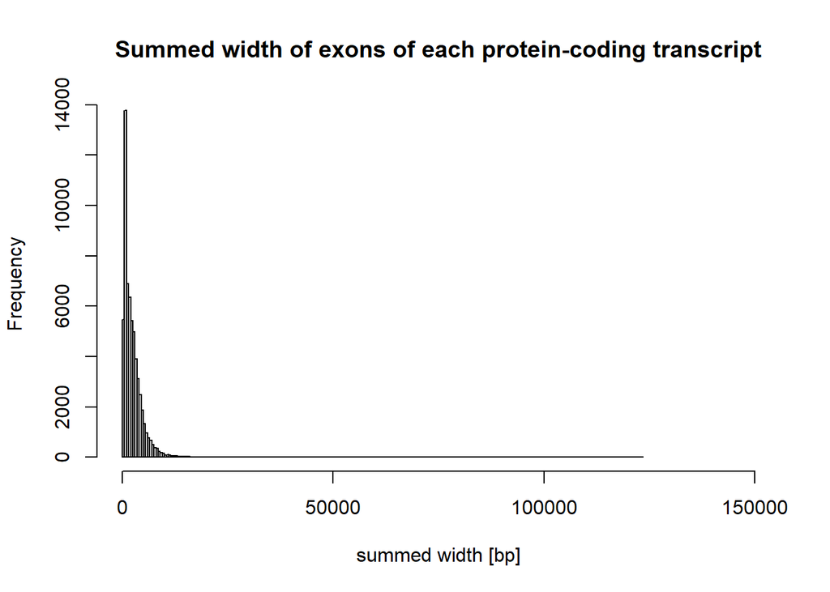

```r
hist(sw_m102exsPerTx_frame$sw_m102exsPerTx,
     breaks=200,
     main= "Summed width of exons of each protein-coding transcript",
     xlab="summed width [bp]",
     xlim=c(0,150000))
```